# presentation

Tong Sun

10/7/2021

# Tidy data

Three principles of tidy data:  
- Every column is a variable.  
- Every row is an observation.  
- Every cell is a single value.

## Messy data

- Column headers are values, not variable names.
- Multiple variables are stored in one column.
- Variables are stored in both rows and columns.
- Multiple types of observational units are stored in the same table.
- A single observational unit is stored in multiple tables.

Example – two subsets – mean years in school in United States & China (men & women)

| Country | X1969 | X1970 | X1971 | X1972 | X1973 | X1974 | X1975 | X1976 | X1977 | X1978 | X1979 | X1980 | X1981 | X1982 | X1983 | X1984 | X1985 | X1986 | X1987 | X1988 | X1989 | X1990 | X1991 | X1992 | X1993 | X1994 | X1995 | X1996 | X1997 | … |
| --- | --- | --- | --- | --- | --- | --- | --- | --- | --- | --- | --- | --- | --- | --- | --- | --- | --- | --- | --- | --- | --- | --- | --- | --- | --- | --- | --- | --- | --- | --- |
| Afghanistan | 1.82 | 1.87 | 1.92 | 1.97 | 2.02 | 2.07 | 2.12 | 2.17 | 2.23 | 2.28 | 2.34 | 2.40 | 2.46 | 2.52 | 2.58 | 2.64 | 2.71 | 2.78 | 2.84 | 2.91 | 2.98 | 3.05 | 3.13 | 3.20 | 3.28 | 3.36 | 3.44 | 3.52 | 3.60 | … |
| Angola | 2.25 | 2.31 | 2.36 | 2.42 | 2.48 | 2.54 | 2.60 | 2.67 | 2.73 | 2.80 | 2.86 | 2.93 | 3.00 | 3.07 | 3.14 | 3.22 | 3.29 | 3.37 | 3.44 | 3.52 | 3.60 | 3.69 | 3.77 | 3.85 | 3.94 | 4.03 | 4.12 | 4.21 | 4.30 | … |
| Albania | 5.47 | 5.58 | 5.69 | 5.80 | 5.91 | 6.02 | 6.13 | 6.24 | 6.36 | 6.47 | 6.59 | 6.71 | 6.83 | 6.95 | 7.06 | 7.19 | 7.31 | 7.43 | 7.55 | 7.67 | 7.80 | 7.92 | 8.05 | 8.17 | 8.30 | 8.43 | 8.55 | 8.68 | 8.81 | … |
| Andorra | 9.16 | 9.30 | 9.44 | 9.58 | 9.72 | 9.86 | 10.00 | 10.10 | 10.30 | 10.40 | 10.60 | 10.70 | 10.80 | 11.00 | 11.10 | 11.20 | 11.40 | 11.50 | 11.70 | 11.80 | 11.90 | 12.10 | 12.20 | 12.30 | 12.40 | 12.60 | 12.70 | 12.80 | 12.90 | … |
| United Arab Emirates | 4.24 | 4.35 | 4.47 | 4.58 | 4.71 | 4.83 | 4.96 | 5.09 | 5.23 | 5.37 | 5.52 | 5.67 | 5.83 | 5.99 | 6.16 | 6.33 | 6.51 | 6.70 | 6.89 | 7.09 | 7.30 | 7.52 | 7.75 | 7.99 | 8.24 | 8.50 | 8.71 | 8.91 | 9.11 | … |
| Argentina | 6.61 | 6.73 | 6.84 | 6.96 | 7.07 | 7.19 | 7.31 | 7.42 | 7.54 | 7.65 | 7.77 | 7.88 | 7.99 | 8.11 | 8.22 | 8.33 | 8.44 | 8.55 | 8.66 | 8.76 | 8.86 | 8.96 | 9.06 | 9.16 | 9.26 | 9.35 | 9.45 | 9.56 | 9.66 | … |
| Armenia | 6.10 | 6.22 | 6.34 | 6.45 | 6.57 | 6.69 | 6.81 | 6.93 | 7.04 | 7.16 | 7.28 | 7.40 | 7.52 | 7.64 | 7.76 | 7.88 | 8.00 | 8.11 | 8.23 | 8.34 | 8.46 | 8.57 | 8.69 | 8.80 | 8.91 | 9.03 | 9.14 | 9.25 | 9.37 | … |
| Antigua and Barbuda | 7.46 | 7.59 | 7.72 | 7.86 | 7.99 | 8.12 | 8.26 | 8.40 | 8.53 | 8.67 | 8.81 | 8.94 | 9.08 | 9.22 | 9.36 | 9.50 | 9.64 | 9.78 | 9.92 | 10.10 | 10.20 | 10.30 | 10.50 | 10.60 | 10.80 | 10.90 | 11.00 | 11.20 | 11.30 | … |
| Australia | 9.06 | 9.20 | 9.34 | 9.48 | 9.62 | 9.76 | 9.90 | 10.00 | 10.20 | 10.30 | 10.40 | 10.60 | 10.70 | 10.90 | 11.00 | 11.10 | 11.30 | 11.40 | 11.50 | 11.60 | 11.80 | 11.90 | 12.00 | 12.10 | 12.20 | 12.40 | 12.50 | 12.60 | 12.70 | … |
| Austria | 7.24 | 7.35 | 7.46 | 7.57 | 7.68 | 7.79 | 7.89 | 8.00 | 8.10 | 8.20 | 8.30 | 8.40 | 8.50 | 8.60 | 8.69 | 8.78 | 8.87 | 8.96 | 9.05 | 9.13 | 9.21 | 9.29 | 9.37 | 9.44 | 9.51 | 9.58 | 9.67 | 9.77 | 9.87 | … |

[output cut: 178 more lines]

| country | X1969 | X1970 | X1971 | X1972 | X1973 | X1974 | X1975 | X1976 | X1977 | X1978 | X1979 | X1980 | X1981 | X1982 | X1983 | X1984 | X1985 | X1986 | X1987 | X1988 | X1989 | X1990 | X1991 | X1992 | X1993 | X1994 | X1995 | X1996 | X1997 | … |
| --- | --- | --- | --- | --- | --- | --- | --- | --- | --- | --- | --- | --- | --- | --- | --- | --- | --- | --- | --- | --- | --- | --- | --- | --- | --- | --- | --- | --- | --- | --- |
| Afghanistan | 0.48 | 0.50 | 0.51 | 0.53 | 0.55 | 0.57 | 0.59 | 0.61 | 0.63 | 0.65 | 0.67 | 0.69 | 0.72 | 0.74 | 0.77 | 0.79 | 0.82 | 0.85 | 0.88 | 0.91 | 0.94 | 0.97 | 1.00 | 1.04 | 1.07 | 1.11 | 1.15 | 1.19 | 1.23 | … |
| Angola | 1.64 | 1.69 | 1.74 | 1.80 | 1.85 | 1.91 | 1.97 | 2.03 | 2.10 | 2.16 | 2.23 | 2.30 | 2.37 | 2.44 | 2.52 | 2.59 | 2.67 | 2.75 | 2.84 | 2.92 | 3.01 | 3.10 | 3.19 | 3.29 | 3.38 | 3.48 | 3.59 | 3.70 | 3.81 | … |
| Albania | 4.99 | 5.11 | 5.24 | 5.36 | 5.49 | 5.62 | 5.75 | 5.88 | 6.02 | 6.15 | 6.29 | 6.43 | 6.57 | 6.71 | 6.85 | 6.99 | 7.13 | 7.28 | 7.42 | 7.57 | 7.72 | 7.87 | 8.02 | 8.17 | 8.32 | 8.47 | 8.62 | 8.77 | 8.93 | … |
| Andorra | 9.50 | 9.67 | 9.84 | 10.00 | 10.20 | 10.30 | 10.50 | 10.70 | 10.80 | 11.00 | 11.20 | 11.30 | 11.50 | 11.70 | 11.80 | 12.00 | 12.20 | 12.30 | 12.50 | 12.60 | 12.80 | 12.90 | 13.10 | 13.20 | 13.40 | 13.50 | 13.70 | 13.80 | 13.90 | … |
| United Arab Emirates | 4.18 | 4.31 | 4.45 | 4.58 | 4.72 | 4.87 | 5.02 | 5.18 | 5.34 | 5.50 | 5.68 | 5.85 | 6.03 | 6.22 | 6.42 | 6.62 | 6.83 | 7.04 | 7.26 | 7.49 | 7.73 | 7.98 | 8.24 | 8.50 | 8.78 | 9.07 | 9.30 | 9.54 | 9.76 | … |
| Argentina | 6.64 | 6.78 | 6.92 | 7.06 | 7.20 | 7.34 | 7.48 | 7.62 | 7.76 | 7.90 | 8.04 | 8.18 | 8.32 | 8.46 | 8.59 | 8.73 | 8.86 | 9.00 | 9.13 | 9.25 | 9.38 | 9.51 | 9.63 | 9.74 | 9.86 | 9.97 | 10.10 | 10.20 | 10.40 | … |
| Armenia | 5.72 | 5.86 | 5.99 | 6.13 | 6.27 | 6.41 | 6.55 | 6.69 | 6.83 | 6.97 | 7.12 | 7.26 | 7.40 | 7.54 | 7.69 | 7.83 | 7.97 | 8.11 | 8.25 | 8.39 | 8.53 | 8.67 | 8.81 | 8.94 | 9.08 | 9.22 | 9.35 | 9.49 | 9.63 | … |
| Antigua and Barbuda | 7.95 | 8.11 | 8.28 | 8.44 | 8.60 | 8.77 | 8.94 | 9.10 | 9.27 | 9.44 | 9.60 | 9.77 | 9.94 | 10.10 | 10.30 | 10.40 | 10.60 | 10.80 | 10.90 | 11.10 | 11.30 | 11.40 | 11.60 | 11.80 | 11.90 | 12.10 | 12.20 | 12.40 | 12.60 | … |
| Australia | 8.91 | 9.07 | 9.23 | 9.39 | 9.54 | 9.70 | 9.86 | 10.00 | 10.20 | 10.30 | 10.50 | 10.60 | 10.80 | 10.90 | 11.10 | 11.20 | 11.30 | 11.50 | 11.60 | 11.80 | 11.90 | 12.00 | 12.20 | 12.30 | 12.40 | 12.50 | 12.60 | 12.80 | 12.90 | … |
| Austria | 6.54 | 6.67 | 6.81 | 6.93 | 7.06 | 7.19 | 7.32 | 7.45 | 7.58 | 7.70 | 7.83 | 7.95 | 8.07 | 8.19 | 8.31 | 8.43 | 8.55 | 8.66 | 8.78 | 8.89 | 8.99 | 9.10 | 9.20 | 9.30 | 9.40 | 9.49 | 9.61 | 9.73 | 9.86 | … |

[output cut: 178 more lines]

| Country | X1969 | X1970 | X1971 | X1972 | X1973 | X1974 | X1975 | X1976 | X1977 | X1978 | X1979 | X1980 | X1981 | X1982 | X1983 | X1984 | X1985 | X1986 | X1987 | X1988 | X1989 | X1990 | X1991 | X1992 | X1993 | X1994 | X1995 | X1996 | X1997 | … |
| --- | --- | --- | --- | --- | --- | --- | --- | --- | --- | --- | --- | --- | --- | --- | --- | --- | --- | --- | --- | --- | --- | --- | --- | --- | --- | --- | --- | --- | --- | --- |
| United States | 11.4 | 11.5 | 11.5 | 11.6 | 11.7 | 11.7 | 11.8 | 11.8 | 11.8 | 11.9 | 11.9 | 11.9 | 12 | 12 | 12 | 12 | 12 | 12 | 12.1 | 12.1 | 12.1 | 12.1 | 12.1 | 12 | 12 | 12 | 12 | 12.1 | 12.1 | … |

| Country | X1969 | X1970 | X1971 | X1972 | X1973 | X1974 | X1975 | X1976 | X1977 | X1978 | X1979 | X1980 | X1981 | X1982 | X1983 | X1984 | X1985 | X1986 | X1987 | X1988 | X1989 | X1990 | X1991 | X1992 | X1993 | X1994 | X1995 | X1996 | X1997 | … |
| --- | --- | --- | --- | --- | --- | --- | --- | --- | --- | --- | --- | --- | --- | --- | --- | --- | --- | --- | --- | --- | --- | --- | --- | --- | --- | --- | --- | --- | --- | --- |
| China | 5.55 | 5.66 | 5.77 | 5.88 | 6 | 6.11 | 6.23 | 6.34 | 6.46 | 6.58 | 6.7 | 6.81 | 6.93 | 7.06 | 7.18 | 7.3 | 7.42 | 7.55 | 7.67 | 7.8 | 7.92 | 8.05 | 8.17 | 8.3 | 8.43 | 8.55 | 8.68 | 8.8 | 8.93 | … |

| Country | X1969 | X1970 | X1971 | X1972 | X1973 | X1974 | X1975 | X1976 | X1977 | X1978 | X1979 | X1980 | X1981 | X1982 | X1983 | X1984 | X1985 | X1986 | X1987 | X1988 | X1989 | X1990 | X1991 | X1992 | X1993 | X1994 | X1995 | X1996 | X1997 | … |
| --- | --- | --- | --- | --- | --- | --- | --- | --- | --- | --- | --- | --- | --- | --- | --- | --- | --- | --- | --- | --- | --- | --- | --- | --- | --- | --- | --- | --- | --- | --- |
| United States | 11.40 | 11.50 | 11.50 | 11.60 | 11.7 | 11.70 | 11.80 | 11.80 | 11.80 | 11.90 | 11.9 | 11.90 | 12.00 | 12.00 | 12.00 | 12.0 | 12.00 | 12.00 | 12.10 | 12.1 | 12.10 | 12.10 | 12.10 | 12.0 | 12.00 | 12.00 | 12.00 | 12.1 | 12.10 | … |
| China | 5.55 | 5.66 | 5.77 | 5.88 | 6.0 | 6.11 | 6.23 | 6.34 | 6.46 | 6.58 | 6.7 | 6.81 | 6.93 | 7.06 | 7.18 | 7.3 | 7.42 | 7.55 | 7.67 | 7.8 | 7.92 | 8.05 | 8.17 | 8.3 | 8.43 | 8.55 | 8.68 | 8.8 | 8.93 | … |

Visualization of the data

mean years in school of men in United States & China

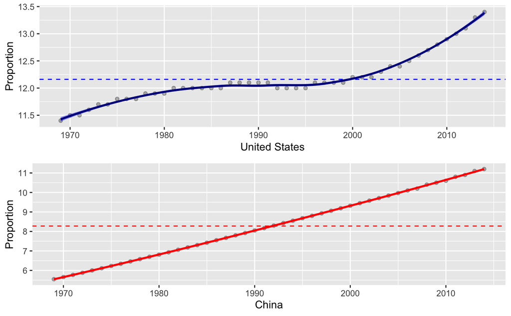

From plot 1, we can find the mean years in school of men all show an increasing trend both in United States and in China. The difference between these two countries is that in United States there is a curve upward trend, while in China there is a straight upward trend. And the mean of the data collected in United States is 12.16, while the mean in China is 8.28. The difference between these two countries is significant. —– mean years in school of women in United States & China

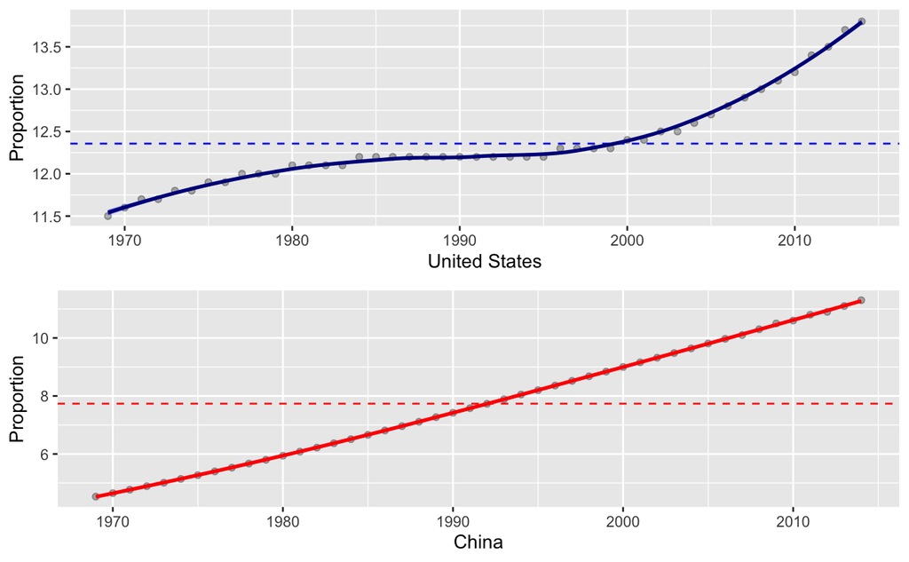

From plot 2, we can find that the average amount of time women spend in school shows a similar trend compared to men in both countries. The mean of the data from United States is 12.36, and from China is 7.74. From above two plots, we can find no matter for men and women, the mean years in school in United States are higher than that in China. —– mean years in school of men & women in United States

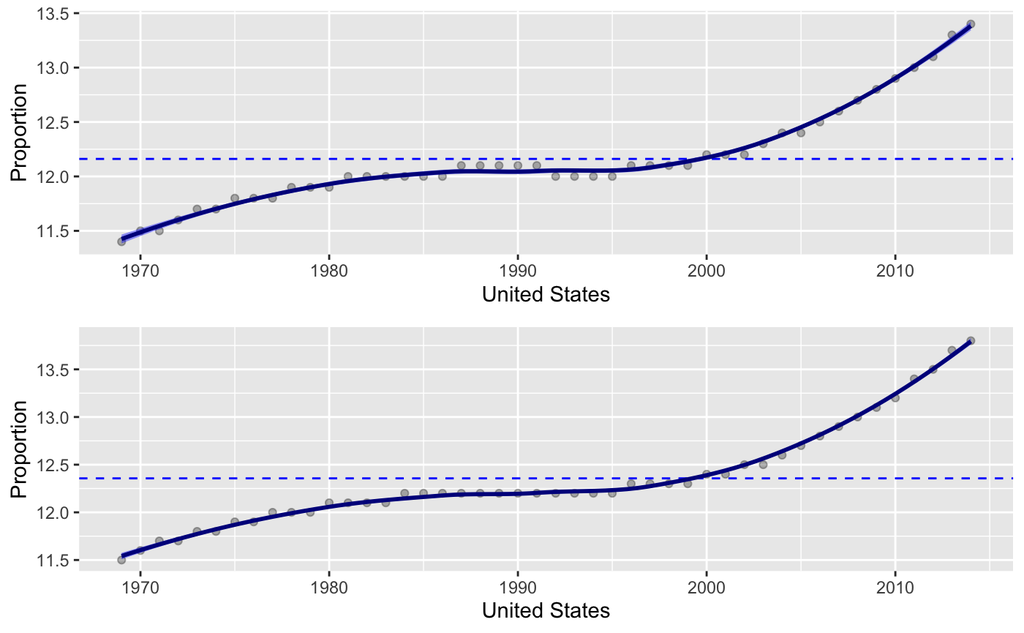

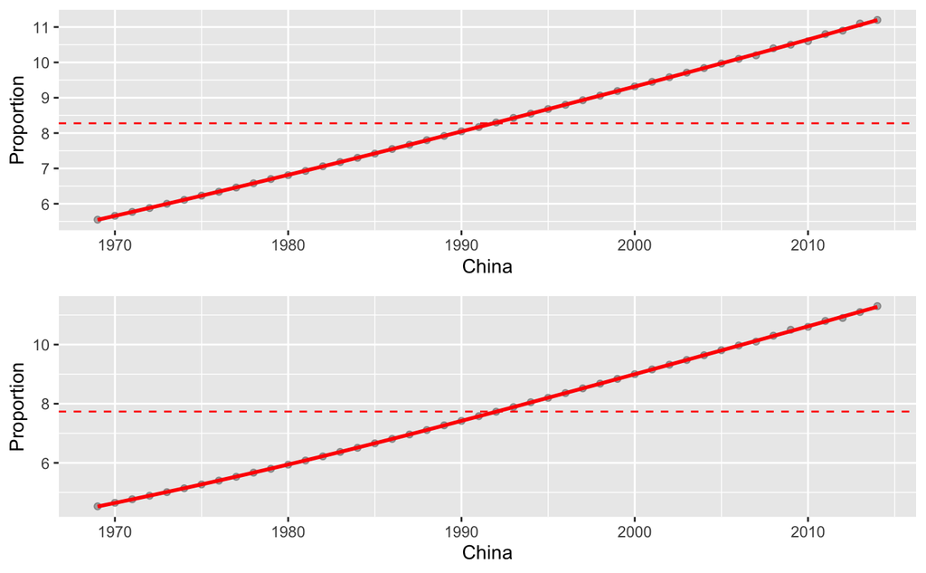

# read the R file visualization_function.R

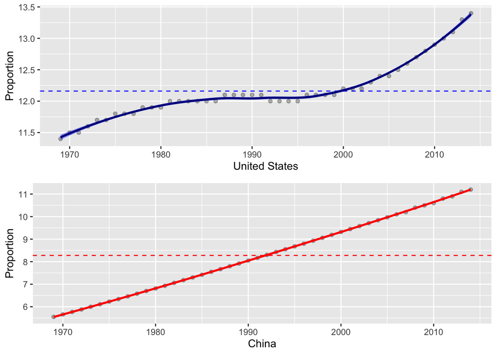

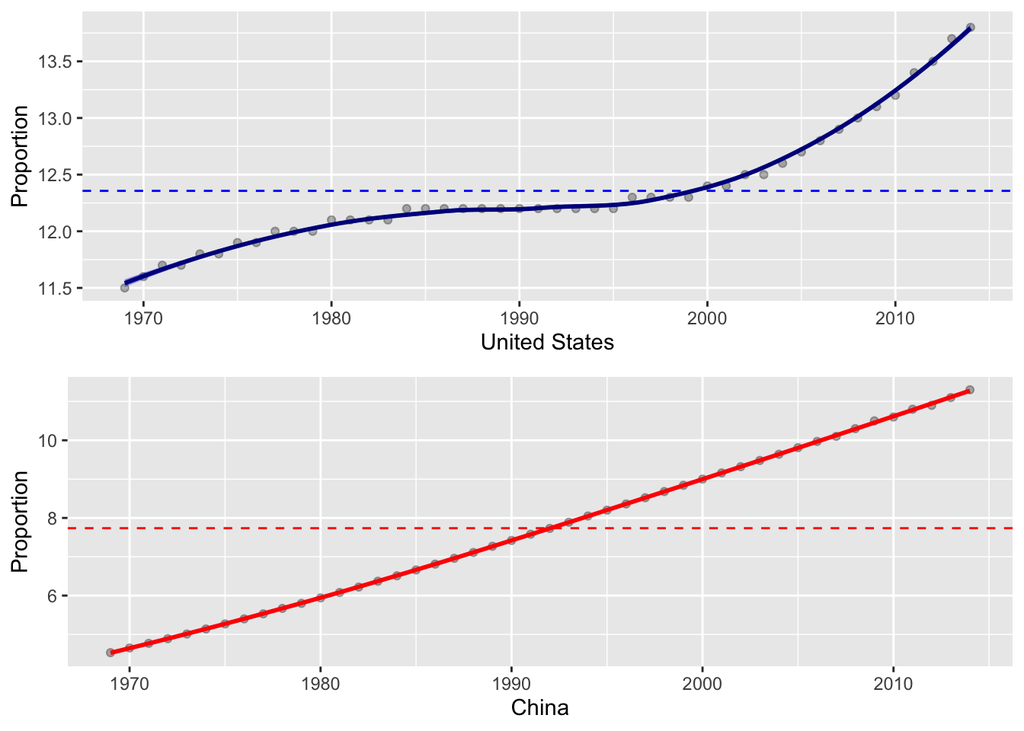

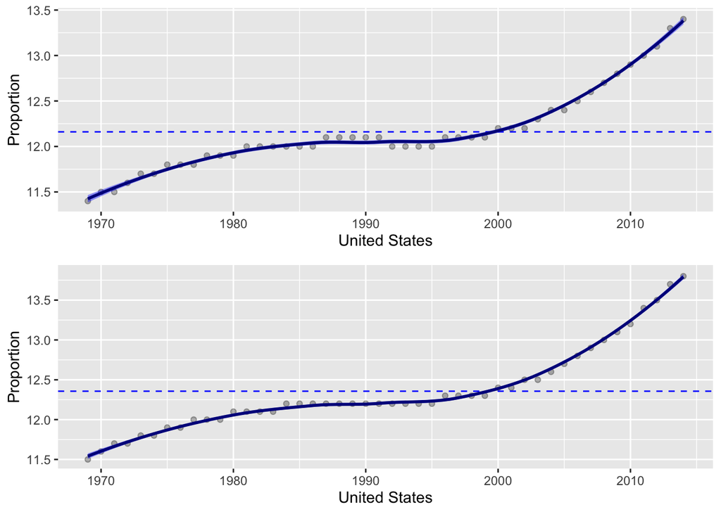

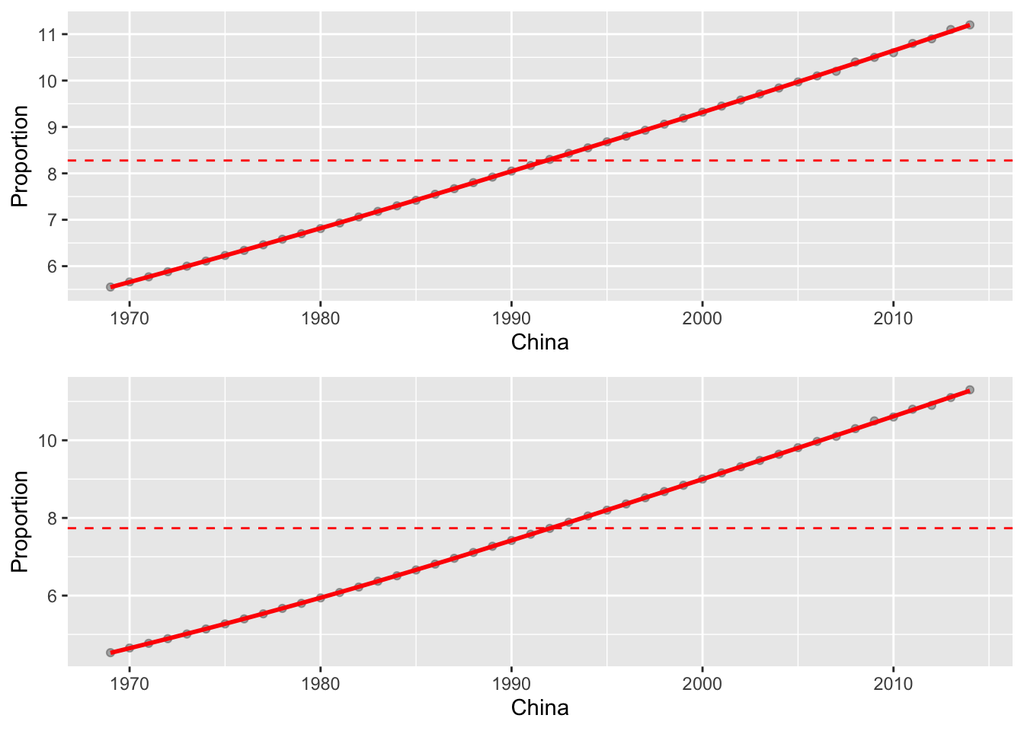